# Actividad # 3 IAM

Jhonatan Smith Garcia c.c 1039705595

Mayo, 2022

# 4.28

Primero, se procede a insertar la base de datos.

```r
datos <- read.table("Datos 4-28.txt", sep= " ", header = T)
```

Para este ejercicio se solicita realizar un analisis de normalidad con el grafico qqmnorm. Entonces:

```r
df.norm <- data.frame(datos[1:5])
```

```
FALSE Warning: package 'mvtnorm' was built under R version 4.0.5
```

```
FALSE Warning: package 'RVAideMemoire' was built under R version 4.0.5
```

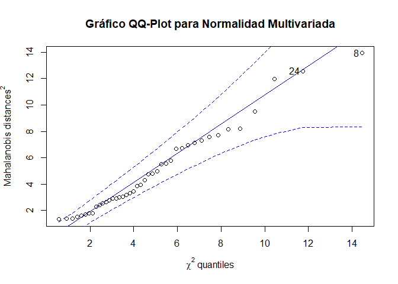

[1] 8 24

```
FALSE Warning: package 'mvnormtest' was built under R version 4.0.3
```

```
Shapiro-Wilk normality test
```

data: Z W = 0.91408, p-value = 0.003908

Dado el juego de hipotesis:

Entonces se concluye que los datos no distribuyen normal puesto que el valor p del estadistico de Shapiro Wilk es menor que un nivel de significancia dado. Por tanto, los datos no son normales.

# 4.29

Se pide realziar un analisis de normalidad bivariada para X5 y X6. Entonces:

```r
df.bi <- datos[,5:6]
head(df.bi)
```

```
##   NO2 O3
## 1  12  8
## 2   9  5
## 3   5  6
## 4   8 15
## 5   8 10
## 6  12 12
```

**a: Distancia de Mahalanobis**

```r
library(data.table)
library(kableExtra)
library(pastecs)
x1 <- df.bi$NO2
x2 <- df.bi$O3
x <-  cbind(x1,x2)

# Vector de medias

media <- apply(x, 2,mean)

#Matriz de var-cov
var<-var(x)
# Uso de la función: mahalanobis

distancias2<-mahalanobis(x,media,var)
a<-round(distancias2,3)    #distancias al cuadrado

b <-matrix(a, nrow = 6, ncol = 7)
b
```

```
##       [,1]   [,2]  [,3]  [,4]  [,5]  [,6]  [,7]
## [1,] 0.461  1.185 5.649 3.009 6.149 0.190 1.898
## [2,] 0.659 10.639 0.316 0.659 1.036 0.461 2.778
## [3,] 2.377  0.139 0.414 2.774 0.139 1.147 8.473
## [4,] 1.628  0.816 0.122 1.036 0.886 7.086 0.637
## [5,] 0.414  1.357 0.899 0.787 0.138 1.458 0.703
## [6,] 0.476  0.623 4.765 3.444 2.249 0.122 1.801
```

Esta es la distancia de mahalanobis.

2. El numero de observaciones que poseen una distancia de una chi-cuadrado con probabilidad $\chi_{2}(0.5)=1.39$ es de 26 (basta con mirar la tabla y comparar).

Por tanto la proporcion pedida es de 26/42

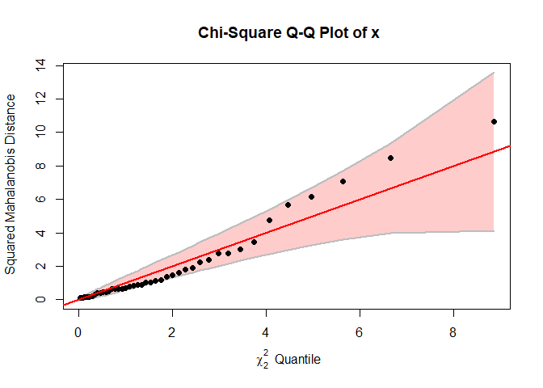

```r
library(heplots)
cqplot(x)
```

# 4.32

```r
datos <- read.table("Tabla1-6.txt", header = F)
head(datos)
```

```
##   V1    V2  V3    V4  V5 V6
## 1 18 152.0 1.6 198.4 0.0  0
## 2 19 138.0 0.4 180.8 1.6  0
## 3 20 144.0 0.0 186.4 0.8  0
## 4 20 143.6 3.2 194.8 0.0  0
## 5 20 148.8 0.0 217.6 0.0  0
## 6 21 141.6 0.8 181.6 0.8  0
```

Se pide analizar normalidad marginal para cada variable.

Ahora, note que por teoria, si un conjunto de variables es normal, entonces cualquier particion de dicho sub conjunto de variables es normal.

Por tanto, se mira si hay normalidad multivariada. Las hipotesis son:

```r
mshapiro.test(t(df.norm))
```

```
##
##  Shapiro-Wilk normality test
##
## data:  Z
## W = 0.91408, p-value = 0.003908
```

¿Existe normalidad para cada variable independiente?

**Pruebas de shaphiro Wilk univariadas**

Para cada variable se está probando que:

$$\begin{aligned}
&H_{0}: X \sim \mathcal{N}\left(\mu, \sigma^{2}\right) \\
&H_{1}: X \nsim \mathcal{N}\left(\mu, \sigma^{2}\right)
\end{aligned}$$

```r
attach(datos)

shapiro.test(V1)
```

```
##
##  Shapiro-Wilk normality test
##
## data:  V1
## W = 0.92961, p-value = 5.615e-05
```

Por el valor p menor que un alfa dado (digamos 0.05) se rechaza la hipotesis nula a favor de la alterna y se concluye datos no normales para V1

```r
shapiro.test(V2)
```

```
##
##  Shapiro-Wilk normality test
##
## data:  V2
## W = 0.8104, p-value = 6.887e-10
```

Por el valor p menor que un alfa dado (digamos 0.05) se rechaza la hipotesis nula a favor de la alterna y se concluye datos no normales para V2

```r
shapiro.test(V3)
```

```
##
##  Shapiro-Wilk normality test
##
## data:  V3
## W = 0.41532, p-value < 2.2e-16
```

Por el valor p menor que un alfa dado (digamos 0.05) se rechaza la hipotesis nula a favor de la alterna y se concluye datos no normales para V3

```r
shapiro.test(V4)
```

```
##
##  Shapiro-Wilk normality test
##
## data:  V4
## W = 0.84311, p-value = 8.578e-09
```

Por el valor p menor que un alfa dado (digamos 0.05) se rechaza la hipotesis nula a favor de la alterna y se concluye datos no normales para V4

```r
shapiro.test(V5)
```

```
##
##  Shapiro-Wilk normality test
##
## data:  V5
## W = 0.44339, p-value < 2.2e-16
```

Por el valor p menor que un alfa dado (digamos 0.05) se rechaza la hipotesis nula a favor de la alterna y se concluye datos no normales para V5

```r
shapiro.test(V6)
```

```
##
##  Shapiro-Wilk normality test
##
## data:  V6
## W = 0.57278, p-value = 1.948e-15
```

Por el valor p menor que un alfa dado (digamos 0.05) se rechaza la hipotesis nula a favor de la alterna y se concluye datos no normales para V6

En un principio, los datos del problema no son normales.

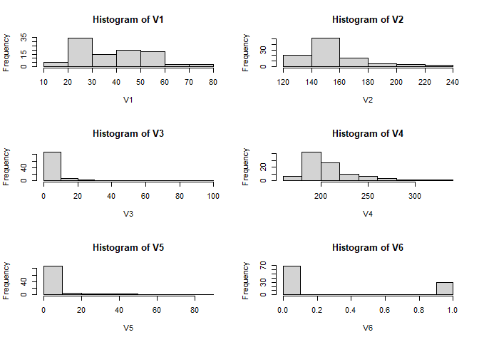

```r
par(mfrow = c(3,2))

hist(V1)
hist(V2)
hist(V3)
hist(V4)
hist(V5)
hist(V6)
```

Se hace un histograma para analizar si tiene sentido realizar algun tipo de transformacion para intentar normalizar los datos.

Se intenta ver patrondes con la densidad de cada variable. Nuevamente:

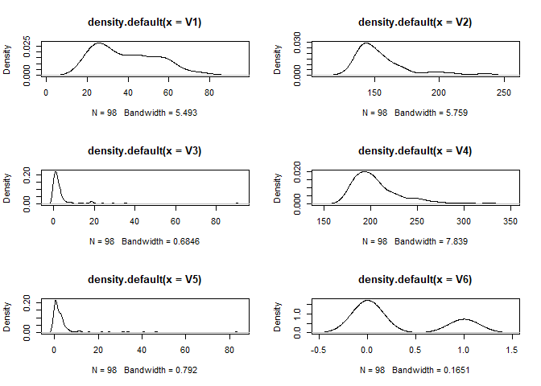

```r
par(mfrow=c(3,2))
plot(density(V1))
plot(density(V2))
plot(density(V3))
plot(density(V4))
plot(density(V5))
plot(density(V6))
```

Realmente es muy dificl ver una tendencia en la distribucion de los datos.

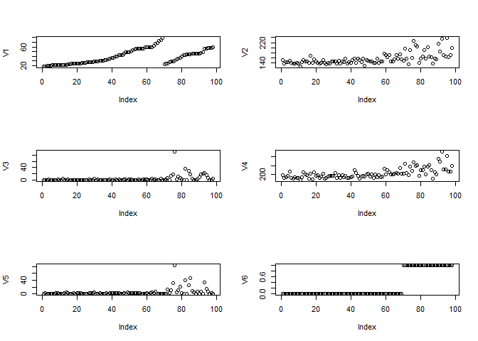

```r
par(mfrow=c(3,2))
plot(V1)
plot(V2)
plot(V3)
plot(V4)
plot(V5)
plot(V6)
```

Dado estos datos, un analisis descriptivo permite ver que ninguna transformacion surgirá algun efecto sobre la normalidad.

# 4.34

El formato de la base de datos está en Minitab y no es compatible con las versiones actualizadas de R.

MiniTab NO es compatible con el correio de la universidad y no hay forma de transformar los archivos de la base de datos a un archivo importable a R

El unico paquete para importar informacion a R es “mtbr” y dicho paquete tambien es creado por Minitab, quienes impiden su descarga a no ser de tener licencia.

Ademas, el paquete que podria funcionar, denominado “foreign” ha sido dado de baja del cran (crashea R) entonces, este ejercicio no es posible resolverlo puesto que no se conoce forma de acceder a la base de datos.

library(rio) library(foreign)

Luego, se harian las ruebas respectivas de normalidad multivarida y bivariada.

#4.36

```r
library(rio)
datos <- import("T1-9.txt")
head(datos)
```

```
##    V1    V2    V3    V4   V5   V6   V7     V8
## 1 ARG 11.57 22.94 52.50 2.05 4.25 9.19 150.32
## 2 AUS 11.12 22.23 48.63 1.98 4.02 8.63 143.51
## 3 AUT 11.15 22.70 50.62 1.94 4.05 8.78 154.35
## 4 BEL 11.14 22.48 51.45 1.97 4.08 8.82 143.05
## 5 BER 11.46 23.05 53.30 2.07 4.29 9.81 174.18
## 6 BRA 11.17 22.60 50.62 1.97 4.17 9.04 147.41
```

Se procede a realizar analisis multivariadnte de normalidad. Las hipotesis son:

```r
data <- data.frame(datos[,2:8])

library(ppcc)
ppccTest(data, "qnorm")
```

```
##
##  Probability Plot Correlation Coefficient Test
##
## data:  data
## ppcc = 0.8177, n = 378, p-value < 2.2e-16
## alternative hypothesis: data differs from a Normal distribution
```

Se procdede a analizar normalidad marginalmente en el caso univariado. Pero primero, se realizan analisis descriptivos respecto a los datos

```r
par(mfrow = c(4,2))
attach(data)
```

[figure not shown]

```r
hist(V2)
hist(V3)
hist(V4)
hist(V5)
hist(V6)
hist(V7)
hist(V8)
```

Se podria esperar normalidad en algunas variables.

```r
shapiro.test(V2)
```

```
##
##  Shapiro-Wilk normality test
##
## data:  V2
## W = 0.96973, p-value = 0.1875
```

Dado el juego de hipotesis anteriormente mencionado para la prueba de shapiro wilk en normalidad univariada, se concuye que V2 es normal.

Las demas variables no lo son.

```r
shapiro.test(V3)
```

```
##
##  Shapiro-Wilk normality test
##
## data:  V3
## W = 0.9538, p-value = 0.0365
```

```r
shapiro.test(V4)
```

```
##
##  Shapiro-Wilk normality test
##
## data:  V4
## W = 0.94455, p-value = 0.0145
```

```r
shapiro.test(V5)
```

```
##
##  Shapiro-Wilk normality test
##
## data:  V5
## W = 0.90487, p-value = 0.0004189
```

```r
shapiro.test(V6)
```

```
##
##  Shapiro-Wilk normality test
##
## data:  V6
## W = 0.83583, p-value = 3.257e-06
```

```r
shapiro.test(V7)
```

```
##
##  Shapiro-Wilk normality test
##
## data:  V7
## W = 0.76319, p-value = 5.99e-08
```

```r
shapiro.test(V8)
```

```
##
##  Shapiro-Wilk normality test
##
## data:  V8
## W = 0.74612, p-value = 2.621e-08
```